# Lab 02 Data Wrangling for Dataframes

## RE 519 Data Analytics and Visualization | Autumn 2025

- Core Functions & Tools Covered in Lab 02
- Lab 02-A: Modifying Dataframes
  - Pipe - A Unique Feature of R
  - Simple Sampling from Dataframes
  - Select Rows or Columns
  - Sort Based on Values
  - Create, Re-define, and Rename Variables
  - 📚 TODO: Modifying Dataframes
- Lab 02-B: Summarizing and Joining Dataframes
  - Summarizing Data
  - Groupby
  - Joining Dataframes
  - Very Simple Git and GitHub
  - 📚 TODO: Summarizing and Joining Dataframes
  - 📚 TODO: Sampling for Central Limit Theorem
  - 📚 TODO: Explore More
  - 📚 TODO: Using GitHub
- Acknowledgement

Throughout the Lab 2, we will learn how to do data wrangling and explore two real estate datasets of King County maintained by [Andy Krause](https://www.andykrause.com/index.html) at Zillow:

You can find the datasets and Readme file in [this repository](https://github.com/andykrause/kingCoData).

The due day for each lab can be found on the [course wesbite](https://www.yuehaoyu.com/data-analytics-visualization/). The submission should include Rmd, html, and any other files required to rerun the codes. **For Lab 1–3, the use of any generative AI tool (ChatGPT, Copilot, etc.) is prohibited**. We will run AI detection on each submission. More information about [Academic Integrity](https://www.yuehaoyu.com/data-analytics-visualization/syllabus/#academic-integrity) and [the Use of AI](https://www.yuehaoyu.com/data-analytics-visualization/syllabus/#use-of-ai).

> **Recommended Reading**  
> [Chapter 4-5, Modern Data Science with R. Baumer et al. 2024.](https://mdsr-book.github.io/mdsr3e/)

## Core Functions & Tools Covered in Lab 02

- Pipe Operators (%>% / |>): Chain functions together left-to-right (Ctrl + Shift + M / Cmd + Shift + M) for clean, readable code.
- Sampling (sample_n() / slice_sample()): Randomly select rows from a data frame (with or without replacement). Combined with set.seed() for reproducibility.
- Subsetting Columns (select()): Pick specific columns by name or drop unwanted ones using select(-col).
- Filtering Rows (filter()): Extract rows meeting conditions using logical operators (==, >, <, %in%, &, |).
- Sorting (arrange()): Order rows by one or more variables in ascending order, or descending order using desc().
- Mutating & Renaming (mutate(), rename()): Create new calculated variables or rename existing ones.
- Summarizing & Grouping (summarize(), group_by()): Compute aggregate statistics (e.g., mean(), median(), n()) overall or grouped by categorical variables.
- Data Joining (left_join(), inner_join(), right_join(), full_join()): Combine two data frames using primary (sale_id) and foreign keys (pinx).

## Lab 02-A: Modifying Dataframes

Let’s first import the datasets and necessary packages. **If you are using a Windows computer**, you need to install [RTools](https://cran.r-project.org/bin/windows/Rtools/) first. After installing this data package with `devtools::install_github('andykrause/kingCoData')`, you can load the data with: `data(kingco_sales)` and `data(kingco_homes)`. You can find the datasets and Readme file in [this repository](https://github.com/andykrause/kingCoData).

```r
library('tidyverse')
#devtools::install_github('andykrause/kingCoData') # You only need to run the installation once
library('kingCoData') # load the data package
data(kingco_sales) # load the sale data
```

```r
# check all column names
colnames(kingco_sales)
```

```
##  [1] "sale_id"          "pinx"             "sale_date"        "sale_price"
##  [5] "sale_nbr"         "sale_warning"     "join_status"      "join_year"
##  [9] "latitude"         "longitude"        "area"             "city"
## [13] "zoning"           "subdivision"      "present_use"      "land_val"
## [17] "imp_val"          "year_built"       "year_reno"        "sqft_lot"
## [21] "sqft"             "sqft_1"           "sqft_fbsmt"       "grade"
## [25] "fbsmt_grade"      "condition"        "stories"          "beds"
## [29] "bath_full"        "bath_3qtr"        "bath_half"        "garb_sqft"
## [33] "gara_sqft"        "wfnt"             "golf"             "greenbelt"
## [37] "noise_traffic"    "view_rainier"     "view_olympics"    "view_cascades"
## [41] "view_territorial" "view_skyline"     "view_sound"       "view_lakewash"
## [45] "view_lakesamm"    "view_otherwater"  "view_other"       "submarket"
```

```r
?kingco_sales
```

We saw a brunch of variables but let’s talk about the first two:

- `sale_id`: The unique transaction identifying code. Primary key for this data! Serves as the **primary key** of the dataset — each row has a distinct `sale_id`.
- `pinx`: The unique property identifying code (Major + Minor). Serves as a **foreign key** linking sales to property records, which is `kingco_homes` in our case.

### Pipe - A Unique Feature of R

One of the most distinctive features of R (especially through the tidyverse) is the pipe operator `%>%` or `|>`.

- chain commands together in a clear, left-to-right order.
- Instead of nesting multiple functions, you can read code step by step.
- closer to natural language and easier to follow in data analysis workflows.

| System | Windows/Linux | Mac |
| --- | --- | --- |
| Pipe Shortcut | Ctrl + Shift + M | Cmd + Shift + M |

```r
library(magrittr)
# example without pipe
mean(log(sqrt(c(2, 3, 4, 5))))
```

```
## [1] 0.5984365
```

```r
# example with pipe
c(1,4,9,16)%>%
  sqrt()%>%
  log()%>%
  mean()
```

```
## [1] 0.7945135
```

### Simple Sampling from Dataframes

We can randomly select some rows from the data using `sample_n()`, every transaction has the same chance of being picked.

```r
library(tidyverse)
library(dplyr)
```

```r
library(kingCoData)
```

```r
random_sample <- kingCoData::kingco_sales %>%
  sample_n(10)
random_sample
```

```
## # A tibble: 10 × 48
##    sale_id     pinx      sale_date  sale_price sale_nbr sale_warning join_status
##    <chr>       <chr>     <date>          <int>    <int> <chr>        <chr>
##  1 2004..18429 ..302309… 2004-05-11     339800        1 "   "        nochg
##  2 2020..4616  ..211320… 2020-02-27     499950       NA "   "        nochg
##  3 2007..22995 ..679510… 2007-06-19     679000        1 "   "        nochg
##  4 2008..5112  ..733540… 2008-03-14     269950        3 "   "        reno - bef…
##  5 2015..32944 ..531510… 2015-09-16    1295000        1 "   "        nochg
##  6 2008..15309 ..548920… 2008-07-03     720000        2 "   "        nochg
##  7 2009..15302 ..375520… 2009-09-03     480000        3 "   "        nochg
##  8 2017..2231  ..731240… 2017-01-30     415000        2 " 26 "       nochg
##  9 2021..368   ..611750… 2021-01-06     918800        3 "   "        nochg
## 10 2016..8207  ..793650… 2016-03-30    1850000        2 " 26 "       nochg
## # ℹ 41 more variables: join_year <dbl>, latitude <dbl>, longitude <dbl>,
## #   area <int>, city <chr>, zoning <chr>, subdivision <chr>, present_use <int>,
## #   land_val <int>, imp_val <int>, year_built <int>, year_reno <int>,
## #   sqft_lot <int>, sqft <int>, sqft_1 <int>, sqft_fbsmt <int>, grade <int>,
## #   fbsmt_grade <int>, condition <int>, stories <dbl>, beds <int>,
## #   bath_full <int>, bath_3qtr <int>, bath_half <int>, garb_sqft <int>,
## #   gara_sqft <int>, wfnt <int>, golf <dbl>, greenbelt <dbl>, …
```

```r
## sample_n is now replaced by slice_sample
random_sample1 <- kingco_sales |> slice_sample(n=5, replace = FALSE)
random_sample1
```

```
## # A tibble: 5 × 48
##   sale_id     pinx       sale_date  sale_price sale_nbr sale_warning join_status
##   <chr>       <chr>      <date>          <int>    <int> <chr>        <chr>
## 1 2002..8796  ..8857640… 2002-03-26     337950        2 "   "        new
## 2 2020..10152 ..7852030… 2020-04-27     650000        5 " 26 "       new
## 3 2017..9943  ..5634500… 2017-04-06     475000        3 "   "        reno - bef…
## 4 1999..27203 ..0869700… 1999-07-23     204950        1 "   "        new
## 5 2020..26085 ..7237550… 2020-09-02    2370000        5 "   "        new
## # ℹ 41 more variables: join_year <dbl>, latitude <dbl>, longitude <dbl>,
## #   area <int>, city <chr>, zoning <chr>, subdivision <chr>, present_use <int>,
## #   land_val <int>, imp_val <int>, year_built <int>, year_reno <int>,
## #   sqft_lot <int>, sqft <int>, sqft_1 <int>, sqft_fbsmt <int>, grade <int>,
## #   fbsmt_grade <int>, condition <int>, stories <dbl>, beds <int>,
## #   bath_full <int>, bath_3qtr <int>, bath_half <int>, garb_sqft <int>,
## #   gara_sqft <int>, wfnt <int>, golf <dbl>, greenbelt <dbl>, …
```

The default setting is **without replacement**, which means each row can appear only once. But we can add additional augment like `sample_n(5, replace = TRUE)`, so that the same row can appear more than once.

If we run the code above several time, we will get different results! Others will not get same results as you did, the codes is NOT reproducible. So, we usually fix the random number generator using `set.seed()`.

```r
set.seed(413) # set seed, then running the same sampling code again will give the same rows
random_sample <- kingco_sales %>%
  sample_n(3)
random_sample
```

```
## # A tibble: 3 × 48
##   sale_id     pinx       sale_date  sale_price sale_nbr sale_warning join_status
##   <chr>       <chr>      <date>          <int>    <int> <chr>        <chr>
## 1 2012..24205 ..1543000… 2012-09-12     375900        3 "   "        new
## 2 2006..46622 ..1796350… 2006-10-23     290000        3 "   "        nochg
## 3 2000..42967 ..1337800… 2000-12-27     900000        1 " 41 "       reno - aft…
## # ℹ 41 more variables: join_year <dbl>, latitude <dbl>, longitude <dbl>,
## #   area <int>, city <chr>, zoning <chr>, subdivision <chr>, present_use <int>,
## #   land_val <int>, imp_val <int>, year_built <int>, year_reno <int>,
## #   sqft_lot <int>, sqft <int>, sqft_1 <int>, sqft_fbsmt <int>, grade <int>,
## #   fbsmt_grade <int>, condition <int>, stories <dbl>, beds <int>,
## #   bath_full <int>, bath_3qtr <int>, bath_half <int>, garb_sqft <int>,
## #   gara_sqft <int>, wfnt <int>, golf <dbl>, greenbelt <dbl>, …
```

```r
random_sample1 <- kingco_sales |> slice_sample(n=3, replace = TRUE)
random_sample1
```

```
## # A tibble: 3 × 48
##   sale_id     pinx       sale_date  sale_price sale_nbr sale_warning join_status
##   <chr>       <chr>      <date>          <int>    <int> <chr>        <chr>
## 1 2025..9443  ..7852130… 2025-05-06    1410000        4 "   "        new
## 2 2013..30590 ..1442880… 2013-09-03     522485        1 "   "        new
## 3 2004..21578 ..1437580… 2004-05-28     856857        2 "   "        new
## # ℹ 41 more variables: join_year <dbl>, latitude <dbl>, longitude <dbl>,
## #   area <int>, city <chr>, zoning <chr>, subdivision <chr>, present_use <int>,
## #   land_val <int>, imp_val <int>, year_built <int>, year_reno <int>,
## #   sqft_lot <int>, sqft <int>, sqft_1 <int>, sqft_fbsmt <int>, grade <int>,
## #   fbsmt_grade <int>, condition <int>, stories <dbl>, beds <int>,
## #   bath_full <int>, bath_3qtr <int>, bath_half <int>, garb_sqft <int>,
## #   gara_sqft <int>, wfnt <int>, golf <dbl>, greenbelt <dbl>, …
```

### Select Rows or Columns

We use `select()` to select and create new dataframe with certain columns. Let’s select a few columns and see whether there are some transactions for the property that can see both Lake Washington and Lake Sammammish.

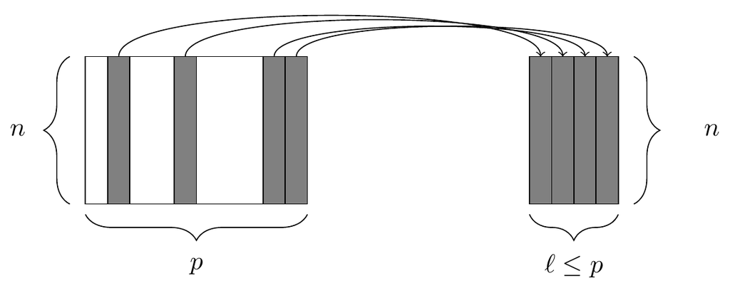

The `select()` function. At left, a data frame, from which we retrieve only a few of the columns. At right, the resulting data frame after selecting those columns. Source: Modern Data Science with R.

```r
# select a few useful columns
kingco_sales_subset <- kingco_sales %>%
  select(sale_id, city, sale_price, sale_date, view_lakewash, view_lakesamm)
```

We use `filter()` function to filter certain rows based on some conditions. We discussed the logical operations in Lab 1, such as `==`, `!=`, `>`, `<=`, `TRUE`, `&`, and `|`.

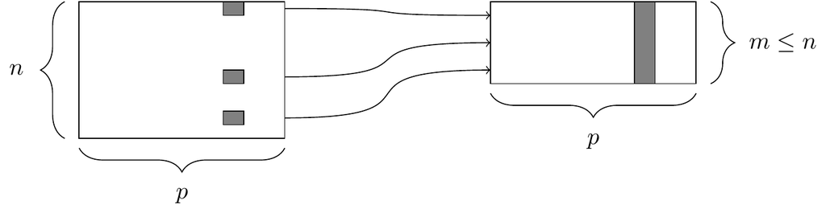

The `filter()` function. At left, a data frame that contains matching entries in a certain column for only a subset of the rows. At right, the resulting data frame after filtering. Source: Modern Data Science with R.

```r
kingco_sales_twolakes <- kingco_sales_subset %>%
  filter(
    view_lakewash == 1,
    view_lakewash == 1,
    sale_date > as.Date("1999-01-01") # after year of 2020
  )
nrow(kingco_sales_twolakes)
```

```
## [1] 6431
```

```r
kingco_sales_twolakes %>%
  filter(
    sale_price < 1500000, # price below 1.5 million
  )
```

```
## # A tibble: 4,818 × 6
##    sale_id     city        sale_price sale_date  view_lakewash view_lakesamm
##    <chr>       <chr>            <int> <date>             <int>         <int>
##  1 1999..6617  SEATTLE         239000 1999-03-02             1             0
##  2 1999..18470 SEATTLE         282155 1999-06-01             1             0
##  3 2000..461   SEATTLE         400000 2000-01-10             1             0
##  4 2000..6299  BELLEVUE        749950 2000-03-15             1             1
##  5 2000..9137  SEATTLE         237450 2000-03-27             1             0
##  6 2000..10801 KIRKLAND        449000 2000-04-12             1             0
##  7 2000..12870 SEATTLE         302209 2000-04-27             1             0
##  8 2000..12885 SEATTLE         241400 2000-04-27             1             0
##  9 2000..13110 KING COUNTY     121000 2000-04-26             1             0
## 10 2000..14168 KENMORE         260000 2000-05-01             1             0
## # ℹ 4,808 more rows
```

If I want to know if any of them are in the BRK region (Bellevue, Redmond, Kirkland), `%in%` checks whether a value belongs to a set of values:

```r
kingco_sales_twolakes %>%
  filter(
    sale_price < 1500000, # price below 1.5 million
    city %in% c('BELLEVUE', 'REDMOND', 'KIRKLAND')
  )
```

```
## # A tibble: 1,198 × 6
##    sale_id     city     sale_price sale_date  view_lakewash view_lakesamm
##    <chr>       <chr>         <int> <date>             <int>         <int>
##  1 2000..6299  BELLEVUE     749950 2000-03-15             1             1
##  2 2000..10801 KIRKLAND     449000 2000-04-12             1             0
##  3 2000..40489 BELLEVUE     405000 2000-11-30             1             1
##  4 2001..2474  KIRKLAND     385000 2001-02-05             1             0
##  5 2001..30849 KIRKLAND     545000 2001-09-14             1             0
##  6 2002..33376 KIRKLAND     350000 2002-10-08             1             1
##  7 2003..9137  KIRKLAND     267000 2003-03-26             1             0
##  8 2004..18088 KIRKLAND     350000 2004-05-18             1             0
##  9 2008..20127 KIRKLAND     750000 2008-08-26             1             0
## 10 2011..3215  KIRKLAND     624000 2011-03-03             1             0
## # ℹ 1,188 more rows
```

We can also remove column(s) by using `select(-)`, for example, removing the columns `view_lakewash` and `view_lakesamm` from dataframe `kingco_sales_twolakes`:

```r
kingco_sales_twolakes_clean <- kingco_sales_twolakes %>%
  select(-c(view_lakewash, view_lakesamm))
head(kingco_sales_twolakes_clean,3)
```

```
## # A tibble: 3 × 4
##   sale_id     city    sale_price sale_date
##   <chr>       <chr>        <int> <date>
## 1 1999..6617  SEATTLE     239000 1999-03-02
## 2 1999..18470 SEATTLE     282155 1999-06-01
## 3 2000..461   SEATTLE     400000 2000-01-10
```

```r
kingco_sales %>%
  filter(
    view_lakewash == 1,
    view_lakesamm == 1,
    sale_date >= as.Date("2020-01-01"),
  ) %>%
  select(pinx, submarket, sale_price, sqft, year_built, grade)
```

```
## # A tibble: 17 × 6
##    pinx         submarket sale_price  sqft year_built grade
##    <chr>        <chr>          <int> <int>      <int> <int>
##  1 ..7526400010 R            1390000  2760       1970     9
##  2 ..7856660230 R            2600000  3190       1977    10
##  3 ..7855801690 R            1790000  2670       1968     9
##  4 ..3897100735 R            2220000  1320       1950     6
##  5 ..1624059148 R            3100000  2560       1968     8
##  6 ..1624059065 R            3000000  1250       1943     6
##  7 ..7856000170 R            1800000  3010       1968     9
##  8 ..9429500255 R            1150000  2400       1955     7
##  9 ..7855400770 R            2200000  3430       1966    10
## 10 ..7855800140 R            1400000  2500       1968     9
## 11 ..9323600550 R            1468000  3340       1979     9
## 12 ..7855800390 R            2165000  3390       1966     8
## 13 ..3459900255 R            1710000  3280       1956     7
## 14 ..4139430580 R            2850000  4490       1998    12
## 15 ..3459900170 R            2050000  3370       1968     9
## 16 ..4139430580 R            2980000  4490       1998    12
## 17 ..4139430630 R            3550000  6690       2001    12
```

If I want to have the view to both lakes, it will cost me a lot. Sad.

### Sort Based on Values

The function `sort()` will sort a vector but not a data frame. The `arrange()` function sorts a data frame.

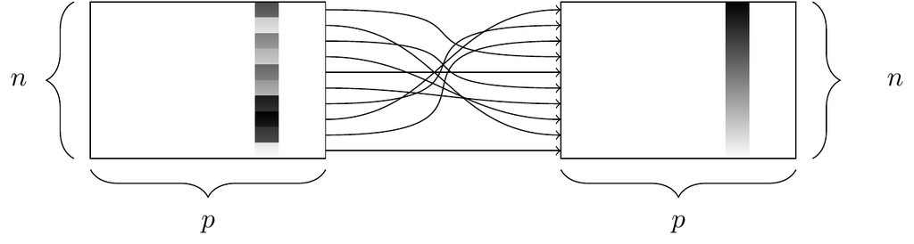

The `arrange()` function. At left, a data frame with an ordinal variable. At right, the resulting data frame after sorting the rows in descending order of that variable. Source: Modern Data Science with R.

```r
kingco_sales_twolakes %>%
  arrange(desc(sale_price))
```

```
## # A tibble: 6,431 × 6
##    sale_id     city        sale_price sale_date  view_lakewash view_lakesamm
##    <chr>       <chr>            <int> <date>             <int>         <int>
##  1 2021..23293 SEATTLE       13300000 2021-06-25             1             0
##  2 2021..24737 BELLEVUE       9800000 2021-06-07             1             0
##  3 2025..10142 SEATTLE        9375000 2025-05-15             1             0
##  4 2024..23660 CLYDE HILL     9100000 2024-10-17             1             0
##  5 2022..22780 BELLEVUE       8750000 2022-07-18             1             0
##  6 2021..39354 CLYDE HILL     8500000 2021-10-06             1             0
##  7 2024..18755 HUNTS POINT    8023000 2024-08-20             1             0
##  8 2022..8821  BELLEVUE       8000000 2022-03-22             1             0
##  9 2024..14811 BELLEVUE       7775000 2024-07-01             1             0
## 10 2020..23468 CLYDE HILL     7565000 2020-08-11             1             0
## # ℹ 6,421 more rows
```

```r
kingco_sales_twolakes %>%
  arrange(sale_price)
```

```
## # A tibble: 6,431 × 6
##    sale_id     city        sale_price sale_date  view_lakewash view_lakesamm
##    <chr>       <chr>            <int> <date>             <int>         <int>
##  1 2000..17081 SEATTLE          83500 2000-05-31             1             0
##  2 2005..3554  RENTON          107966 2005-02-07             1             0
##  3 2000..13110 KING COUNTY     121000 2000-04-26             1             0
##  4 2001..38301 SEATTLE         123000 2001-12-03             1             0
##  5 1999..6276  SEATTLE         123000 1999-03-02             1             0
##  6 1999..16594 RENTON          125000 1999-05-21             1             0
##  7 1999..1122  RENTON          130000 1999-01-19             1             0
##  8 1999..18825 SEATTLE         130000 1999-06-01             1             0
##  9 2014..40677 SEATTLE         133000 2014-12-20             1             0
## 10 1999..44794 RENTON          135000 1999-12-10             1             0
## # ℹ 6,421 more rows
```

Note: We use `desc()` because the default sort order is ascending. If we want ascending order, we don’t need to provide any argument.

### Create, Re-define, and Rename Variables

Currently, we have the columns for view to Lake Washington and Lake Sammammish separately, we can use `mutate` to create a new 1/0 binary variable to indicate. Meanwhile, it’s hard to count the number like 1390000; let’s add a new variable with million dollars as the unit.

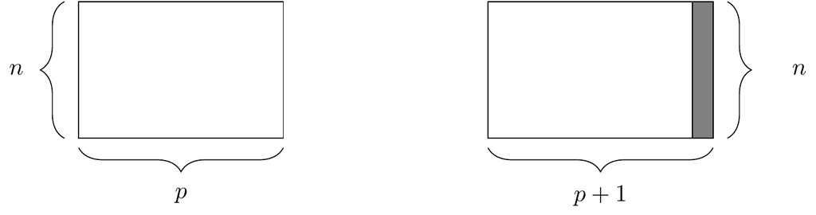

The `mutate()` function. At right, the resulting data frame after adding a new column. Source: Modern Data Science with R.

```r
kingco_sales_add <- kingco_sales %>%
  mutate(
    sale_price_million = sale_price / 1e6, # 1e6 is scientific notation for 1 * 10^6 = 1,000,000
    view_likes = ifelse(view_lakewash == 1 & view_lakesamm == 1, 1, 0)
  )
```

Here we use `ifelse(test, yes, no)`, which is a vectorized conditional function in R: if the test condition is TRUE, it returns the value in yes, and vice versa.

Oops, we wrote `view_likes` as the column name for the binary variable to indicate with the view to both LAKES. We can use `rename()` function to change.

```r
# `kingco_sales_add <- kingco_sales_add`: overwrite it with a modified version of itself after applying more transformations using %>%
kingco_sales_add <- kingco_sales_add %>%
  rename(view_lakewash_lakesamm = view_likes)
```

We can recode variables based on some conditions. For example, we want, in `city` of `kingco_sales_twolakes`, BRK region can be represented by `BRK` rather than separate city names. This operation is based on `recode()`. Similarly, `case_when()` can be used for more flexible recoding, creating categories based on sale price ranges.

```r
kingco_sales %>%
  mutate(
    price_category = case_when(
      sale_price < 500000   ~ "Low",
      sale_price < 1000000  ~ "Mid",
      TRUE                  ~ "High" # for others, we set as 'High'
    ),
    city_group = recode_values(
      city,
      "BELLEVUE" ~ "BRK",
      "REDMOND"  ~ "BRK",
      "KIRKLAND" ~ "BRK"
    )
  )
```

```
## # A tibble: 605,614 × 50
##    sale_id    pinx       sale_date  sale_price sale_nbr sale_warning join_status
##    <chr>      <chr>      <date>          <int>    <int> <chr>        <chr>
##  1 1999..144  ..2734100… 1999-01-05     150000        1 "   "        demo
##  2 1999..258  ..1535200… 1999-01-05     235000        1 "   "        demo
##  3 1999..379  ..9214400… 1999-01-08     190000        1 "   "        demo
##  4 1999..591  ..8815400… 1999-01-05     198000        1 "   "        demo
##  5 1999..775  ..1939800… 1999-01-07     270000        1 "   "        demo
##  6 1999..815  ..5379200… 1999-01-13     159900        1 "   "        demo
##  7 1999..957  ..5210200… 1999-01-15     184250        1 "   "        demo
##  8 1999..1072 ..5101404… 1999-01-15     113000        1 "   "        demo
##  9 1999..1155 ..3438501… 1999-01-19     175000        1 "   "        demo
## 10 1999..1267 ..0616000… 1999-01-11     359850       NA "   "        demo
## # ℹ 605,604 more rows
## # ℹ 43 more variables: join_year <dbl>, latitude <dbl>, longitude <dbl>,
## #   area <int>, city <chr>, zoning <chr>, subdivision <chr>, present_use <int>,
## #   land_val <int>, imp_val <int>, year_built <int>, year_reno <int>,
## #   sqft_lot <int>, sqft <int>, sqft_1 <int>, sqft_fbsmt <int>, grade <int>,
## #   fbsmt_grade <int>, condition <int>, stories <dbl>, beds <int>,
## #   bath_full <int>, bath_3qtr <int>, bath_half <int>, garb_sqft <int>, …
```

### 📚 TODO: Modifying Dataframes

**4 points**

Using the dataset `kingco_homes` and the operations we learned, especially pipe ( %>% ), to finish following tasks:

1. Select the columns: `pinx`, `city`, `land_val`, `imp_val`, `sqft`, `view_lakewash`, `view_lakesamm`
2. Filter the rows: all properties in Bellevue
3. Add a new variable called `total_val` which represents the sum of `land_val` (land value) and `imp_val` (improvements value)
4. Sort the dataframe based on `total_val` in descending order, and show the first 10 records using `head()`
5. Calculate the average (mean value) and variance of `total_val` for:
   - all properties in Bellevue
   - all properties with the view to both Lake Washington and Sammammish in Bellevue
6. Report the difference in average and variance

```r
library(dplyr)
library(kingCoData)

bellevue <- kingco_sales |>
  select(pinx, city, land_val, imp_val, sqft, view_lakewash, view_lakesamm) |>
  filter(city == "BELLEVUE") |>
  mutate(total_val = land_val + imp_val) |>
  arrange(desc(total_val))

head(bellevue, 10)
```

```
## # A tibble: 10 × 8
##    pinx       city  land_val imp_val  sqft view_lakewash view_lakesamm total_val
##    <chr>      <chr>    <int>   <int> <int>         <int>         <int>     <int>
##  1 ..2498100… BELL… 10289000  1.04e7  8855             4             0  20669000
##  2 ..5627300… BELL…  8181000  1.19e7 10990             4             0  20127000
##  3 ..5627300… BELL…  8181000  1.19e7 10990             4             0  20127000
##  4 ..5627300… BELL…  8181000  1.19e7 10990             4             0  20127000
##  5 ..4389200… BELL… 10907000  8.67e6  6570             4             0  19573000
##  6 ..4389200… BELL… 10641000  7.92e6  9790             4             0  18564000
##  7 ..4389200… BELL… 10641000  7.92e6  9790             4             0  18564000
##  8 ..4389200… BELL… 11014000  6.66e6  8650             4             0  17677000
##  9 ..2498100… BELL… 10719000  4.44e6  6280             4             0  15155000
## 10 ..9502200… BELL…  6173000  7.55e6  7340             3             0  13722000
```

```r
all_bellevue <- bellevue |>
  summarise(
    mean_total_val = mean(total_val, na.rm = TRUE),
    var_total_val  = var(total_val, na.rm = TRUE)
  )

both_views <- bellevue |>
  filter(view_lakewash == 1, view_lakesamm == 1) |>
  summarise(
    mean_total_val = mean(total_val, na.rm = TRUE),
    var_total_val  = var(total_val, na.rm = TRUE)
  )

all_bellevue
```

```
## # A tibble: 1 × 2
##   mean_total_val var_total_val
##            <dbl>         <dbl>
## 1       1742235. 998749401753.
```

```r
both_views
```

```
## # A tibble: 1 × 2
##   mean_total_val var_total_val
##            <dbl>         <dbl>
## 1        1517918       1.61e12
```

```r
tibble(
  mean_difference = both_views$mean_total_val - all_bellevue$mean_total_val,
  var_difference  = both_views$var_total_val  - all_bellevue$var_total_val
)
```

```
## # A tibble: 1 × 2
##   mean_difference var_difference
##             <dbl>          <dbl>
## 1        -224317.  612886820977.
```

## Lab 02-B: Summarizing and Joining Dataframes

### Summarizing Data

`summary()` is a base R built-in function that provides quick descriptive statistics. For dataframes, it applies `summary()` to each variable.

```r
summary(kingco_sales[, c("pinx", "sale_date", "land_val")])
```

```
##         pinx          sale_date             land_val
##  Length   :605614   Min.   :1999-01-01   Min.   :       0
##  N.unique :347905   1st Qu.:2004-12-22   1st Qu.:  257000
##  N.blank  :     0   Median :2012-09-13   Median :  397000
##  Min.nchar:    12   Mean   :2012-02-08   Mean   :  500171
##  Max.nchar:    12   3rd Qu.:2018-12-20   3rd Qu.:  647000
##                     Max.   :2025-12-31   Max.   :35124000
```

You may notice that we are using `kingco_sales[, c("pinx", "sale_date", "land_val")]` instead of `select()` to get the columns. This is the base R way of extracting something from vectors, lists, or even dataframes , while `select()` comes from `dplyr`. Both return the same result, but `select()` is usually preferred in a tidyverse workflow because it is more readable and flexible. You can learn more about `[]` by looking at `?Extract`.

We always want to know more than what `summary()` can provide, `summarize()` (same as `summarise()`) is a function in `dplyr` to summarise each group down to one row. But how do we want to summarise a dataframe? Let’s test with our `kingco_sales` data.

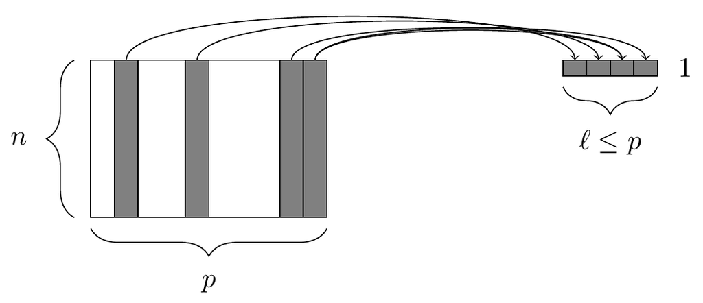

Suppose we want to explore all transactions in Seattle after Jan 1, 2020.

```r
kingco_sales %>%
  filter( # find all transactions in Seattle after Jan 1, 2020 first
    city == "SEATTLE",
    sale_date >= as.Date("2020-1-1")
  ) %>%
  summarise(
    N = n(), # number of rows
    avg_sale_price = mean(sale_price), # average sale price
    highest_sale_price = max(sale_price), # max sale price
    percent_view_rainier = sum(view_rainier)/n() * 100, # percentage of those sales with a Rainier view
    unique_property = length(unique(pinx)) # the number of unique property in all transactions
  )
```

```
## # A tibble: 1 × 5
##       N avg_sale_price highest_sale_price percent_view_rainier unique_property
##   <int>          <dbl>              <int>                <dbl>           <int>
## 1 39769       1076756.           17000000                 1.46           36408
```

```r
colnames(kingco_sales)
```

```
##  [1] "sale_id"          "pinx"             "sale_date"        "sale_price"
##  [5] "sale_nbr"         "sale_warning"     "join_status"      "join_year"
##  [9] "latitude"         "longitude"        "area"             "city"
## [13] "zoning"           "subdivision"      "present_use"      "land_val"
## [17] "imp_val"          "year_built"       "year_reno"        "sqft_lot"
## [21] "sqft"             "sqft_1"           "sqft_fbsmt"       "grade"
## [25] "fbsmt_grade"      "condition"        "stories"          "beds"
## [29] "bath_full"        "bath_3qtr"        "bath_half"        "garb_sqft"
## [33] "gara_sqft"        "wfnt"             "golf"             "greenbelt"
## [37] "noise_traffic"    "view_rainier"     "view_olympics"    "view_cascades"
## [41] "view_territorial" "view_skyline"     "view_sound"       "view_lakewash"
## [45] "view_lakesamm"    "view_otherwater"  "view_other"       "submarket"
```

### Groupby

One important and useful function is `group_by`. We know that, before giving data to `summarise()`, we already select all transactions in Seattle. However, many times, we care about the differences across the groups, like Seattle vs. Redmond. Those city information are categorical data in the column `city`. We can easily use `group_by` to summarise by group. Now, we want to explore all transactions after Jan 1, 2020 across cities.

```r
kingco_sales %>%
  filter( # find all transactions after Jan 1, 2020 first
    sale_date >= as.Date("2020-1-1")
  ) %>%
  group_by(city) %>% # group by city and same `summarise()` will be carried out for each city
  summarise(
    N = n(),
    avg_sale_price = mean(sale_price),
    highest_sale_price = max(sale_price),
    percent_view_rainier = sum(view_rainier)/n() * 100,
    unique_property = length(unique(pinx))
  ) %>%
  arrange(desc(avg_sale_price))
```

```
## # A tibble: 41 × 6
##    city              N avg_sale_price highest_sale_price percent_view_rainier
##    <chr>         <int>          <dbl>              <int>                <dbl>
##  1 HUNTS POINT      38       7636513.           63000000                0
##  2 YARROW POINT     75       5262360.           18000000                0
##  3 MEDINA          264       5035193.           20000000                2.27
##  4 CLYDE HILL      236       4387532.           12225000                1.69
##  5 MERCER ISLAND  1514       2719226.           28500000                9.64
##  6 BEAUX ARTS       29       2698817.            5295000                0
##  7 BELLEVUE       6194       1938376.           26000000                1.00
##  8 KIRKLAND       5278       1647958.           15400000                0.872
##  9 SAMMAMISH      4665       1600511.            7000000                0.386
## 10 NEWCASTLE       877       1568284.            4180000                0.456
## # ℹ 31 more rows
## # ℹ 1 more variable: unique_property <int>
```

### Joining Dataframes

We mentioned two variables are keys: `sale_id` and `pinx`. `pinx`, property ID, exists in both datasets, which serves as the **primary key** for `kingco_homes` — each row has a distinct `pinx`. Meanwhile, it is a **foreign key** in `kingco_sales`: in `kingco_sales`, same property can associate with more than one transactions.

| Variable | kingco_sales | kingco_homes |
| --- | --- | --- |
| sale_id | ✔️ (unique transaction ID, primary key) | ❌ (not included) |
| pinx | ✔️ (property ID, foreign key) | ✔️ (property ID, primary key) |

If we want to join those two dataframes, `pinx` is the only “shared knowledge” we have for both datasets. Joining them is a little bit complicated, let’s use a simple example.

```r
df1 <- data.frame(
  id = c(1, 2, 3),
  name = c("Tom", "Jerry", "Spike") # Tom, Jerry, and the bulldog called Spike
)

df2 <- data.frame(
  id = c(2, 3, 4, 2),
  score = c(85, 90, 95, 87) # notice that we have two records for id = 2 (Jerry)
)
```

```r
# inner join: keeps only rows where id exists in both data frames
inner_join(df1, df2, by = "id")
```

```
##   id  name score
## 1  2 Jerry    85
## 2  2 Jerry    87
## 3  3 Spike    90
```

```r
# left join: keeps all rows from df1 (left table). If no match in df2, fill with NA.
left_join(df1, df2, by = "id")
```

```
##   id  name score
## 1  1   Tom    NA
## 2  2 Jerry    85
## 3  2 Jerry    87
## 4  3 Spike    90
```

```r
# right join: keeps all rows from df2 (right table). If no match in df1, fill with NA.
right_join(df1, df2, by = "id")
```

```
##   id  name score
## 1  2 Jerry    85
## 2  2 Jerry    87
## 3  3 Spike    90
## 4  4  <NA>    95
```

```r
# full join: keeps all rows from both tables. Missing values are filled with NA.
full_join(df1, df2, by = "id")
```

```
##   id  name score
## 1  1   Tom    NA
## 2  2 Jerry    85
## 3  2 Jerry    87
## 4  3 Spike    90
## 5  4  <NA>    95
```

#### Joining King County Datasets

Back to our datasets, let’s first check the differences between `pinx` in both datasets.

```r
# check whether kingco_sales$pinx are all in kingco_homes$pinx
all(kingco_sales$pinx %in% kingco_homes$pinx)
```

```
## [1] FALSE
```

```r
# check the number of `pinx` values from sales are not in homes
setdiff(kingco_sales$pinx, kingco_homes$pinx) %>%
  length()
```

```
## [1] 6695
```

If we want to focus on `kingco_sales` and use `kingco_homes` as attributes of those transactions, we can use `left_join()`. (Also `right_join()` if you put `kingco_sales` on the right.)

```r
kingco_sales_w_info <- left_join(kingco_sales, kingco_homes, by = "pinx")
```

```
## Warning in left_join(kingco_sales, kingco_homes, by = "pinx"): Detected an unexpected many-to-many relationship between `x` and `y`.
## ℹ Row 11399 of `x` matches multiple rows in `y`.
## ℹ Row 218229 of `y` matches multiple rows in `x`.
## ℹ If a many-to-many relationship is expected, set `relationship =
##   "many-to-many"` to silence this warning.
```

```r
head(kingco_sales_w_info, 3)
```

```
## # A tibble: 3 × 88
##   sale_id   pinx         sale_date  sale_price sale_nbr sale_warning join_status
##   <chr>     <chr>        <date>          <int>    <int> <chr>        <chr>
## 1 1999..144 ..2734100475 1999-01-05     150000        1 "   "        demo
## 2 1999..258 ..1535200725 1999-01-05     235000        1 "   "        demo
## 3 1999..379 ..9214400005 1999-01-08     190000        1 "   "        demo
## # ℹ 81 more variables: join_year <dbl>, latitude.x <dbl>, longitude.x <dbl>,
## #   area.x <int>, city.x <chr>, zoning.x <chr>, subdivision.x <chr>,
## #   present_use.x <int>, land_val.x <int>, imp_val.x <int>, year_built.x <int>,
## #   year_reno.x <int>, sqft_lot.x <int>, sqft.x <int>, sqft_1.x <int>,
## #   sqft_fbsmt.x <int>, grade.x <int>, fbsmt_grade.x <int>, condition.x <int>,
## #   stories.x <dbl>, beds.x <int>, bath_full.x <int>, bath_3qtr.x <int>,
## #   bath_half.x <int>, garb_sqft.x <int>, gara_sqft.x <int>, wfnt.x <int>, …
```

#### We Have a Problem….

Oops, we received the warning from R: Detected an unexpected many-to-many relationship between `x` and `y`. We expect there are multiple `pinx` in transaction data but `pinx` should be unique in home data. That happens all the time when you work as a data analyst: all kinds of messy and unexpected data issues. Handling these challenges carefully is an essential part of real-world data analysis.

Let’s investigate duplicates.

```r
kingco_homes %>%
  add_count(pinx) %>%  # add the count of `pinx` as a new column
  filter(n > 1) %>%  # find duplicated properties
  head(3) # I add `head()` because otherwise all rows will be shown on the html when I knit this Rmd
```

```
##           pinx latitude longitude area     city zoning
## 1 ..2420069353 47.20694 -121.9872   41 ENUMCLAW    R-4
## 2 ..2420069353 47.20694 -121.9872   41 ENUMCLAW    R-4
## 3 ..6392000550 47.68469 -122.2892   45  SEATTLE    NR3
##                 subdivision present_use land_val imp_val year_built year_reno
## 1                                     2        0       0       1938         0
## 2                                     2   196000  295000       1938         0
## 3 ONEIDA GARDENS ADD REPLAT           2   320500   10500       1947         0
##   sqft_lot sqft sqft_1 sqft_fbsmt grade fbsmt_grade condition stories beds
## 1     5500 1440    960        480     6           5         5       1    3
## 2     5500 1440    960        480     6           5         5       1    3
## 3     6000  990    990          0     7           0         3       1    2
##   bath_full bath_3qtr bath_half garb_sqft gara_sqft wfnt golf greenbelt
## 1         1         1         0       240         0    0    0         0
## 2         1         1         0       240         0    0    0         0
## 3         1         0         0         0         0    0    0         0
##   noise_traffic view_rainier view_olympics view_cascades view_territorial
## 1             0            0             0             0                0
## 2             0            0             0             0                0
## 3             0            0             0             0                0
##   view_skyline view_sound view_lakewash view_lakesamm view_otherwater
## 1            0          0             0             0               0
## 2            0          0             0             0               0
## 3            0          0             0             0               0
##   view_other submarket n
## 1          0         M 2
## 2          0         M 2
## 3          0         C 2
```

We found `land_val` and `imp_val` are different while others are same in general. To simplify the problem, we can assume `land_val` and `imp_val` may be different while others are same. Also, we should select rows with high total values.

```r
kingco_homes_clean <- kingco_homes %>%
  distinct() %>% # drop any completely duplicate rows
  group_by(pinx) %>%
  slice_max(order_by = land_val + imp_val, n = 1, with_ties = FALSE) %>% # within each group, keep just the one row with the largest total
  ungroup() # remove the grouping so the result is a normal data frame again
```

Join them again and we will not receive the warning.

```r
kingco_sales_w_clean_info <- left_join(kingco_sales, kingco_homes_clean, by = "pinx")
head(kingco_sales_w_clean_info, 3)
```

```
## # A tibble: 3 × 88
##   sale_id   pinx         sale_date  sale_price sale_nbr sale_warning join_status
##   <chr>     <chr>        <date>          <int>    <int> <chr>        <chr>
## 1 1999..144 ..2734100475 1999-01-05     150000        1 "   "        demo
## 2 1999..258 ..1535200725 1999-01-05     235000        1 "   "        demo
## 3 1999..379 ..9214400005 1999-01-08     190000        1 "   "        demo
## # ℹ 81 more variables: join_year <dbl>, latitude.x <dbl>, longitude.x <dbl>,
## #   area.x <int>, city.x <chr>, zoning.x <chr>, subdivision.x <chr>,
## #   present_use.x <int>, land_val.x <int>, imp_val.x <int>, year_built.x <int>,
## #   year_reno.x <int>, sqft_lot.x <int>, sqft.x <int>, sqft_1.x <int>,
## #   sqft_fbsmt.x <int>, grade.x <int>, fbsmt_grade.x <int>, condition.x <int>,
## #   stories.x <dbl>, beds.x <int>, bath_full.x <int>, bath_3qtr.x <int>,
## #   bath_half.x <int>, garb_sqft.x <int>, gara_sqft.x <int>, wfnt.x <int>, …
```

### Very Simple Git and GitHub

- Every change you make is saved in history, so you can always go back.
- If something breaks, you can roll back to a working version.
- Multiple people can work on the same project without overwriting each other.
- Your code and documents are safe, even if your computer crashes.
- Most of the data science ecosystem (R packages, Python libraries, statistical models, tutorials) lives on GitHub.

There are two main ways to use GitHub:

1. Terminal (Command Line) – more powerful and professional, gives you full control.
2. [GitHub Desktop](https://github.com/apps/desktop) – easier for beginners, has a user-friendly interface.

We will using GitHub Desktop:

1. Download and install [GitHub Desktop](https://github.com/apps/desktop).
2. [Sign up a free GitHub account](https://github.com/signup).
3. Sign in with your GitHub account on GitHub Desktop.
4. Create a [new public repository](https://github.com/new).
5. Go to your Github Desktop -> File->Click “Clone a repository” to copy from GitHub to your computer.
6. Add this `.Rmd` and `html` to your local repository.
7. Commit changes with a short message (e.g., “Lab 3 for RE 519”).
8. Click “Push origin” to upload your changes back to GitHub.
9. You can check your changes on GitHub now.

We only covered every basic of Git and GitHub, you can learn more on the logic behind Git using [Learn Git Branching](https://learngitbranching.js.org).

### 📚 TODO: Summarizing and Joining Dataframes

**2 points**

Let’s use the `kingco_homes_clean` data to do some summarise and analysis.

For all property in Seattle, what’s the average total values per sqft [(`land_val` + `imp_val`)/`sqft`] by condition? Also, add the count of properties in each group in the summary table.

```r
kingco_homes_clean |>
  filter(city == "SEATTLE") |>
  mutate(val_per_sqft = (land_val + imp_val) / sqft) |>
  group_by(condition) |>
  summarise(
    avg_val_per_sqft = mean(val_per_sqft, na.rm = TRUE),
    count = n()
  )
```

```
## # A tibble: 5 × 3
##   condition avg_val_per_sqft  count
##       <int>            <dbl>  <int>
## 1         1             521.    130
## 2         2             542.   1349
## 3         3             Inf  103786
## 4         4             591.  32446
## 5         5             621.  12532
```

### 📚 TODO: Sampling for Central Limit Theorem

**4 points**

We are going to use the sale price data to understand one of the most important theorems in statistics, [Central Limit Theorem (CLT)](https://en.wikipedia.org/wiki/Central_limit_theorem). I *highly* recommend [the visualization](https://pmplewa.github.io/clt.html) and [this video from 3Blue1Brown](https://www.youtube.com/watch?v=zeJD6dqJ5lo&t=68s) to understand CLT.

```r
# filter transactions after 2020 in Bellevue
bellevue_after2020 <- kingco_sales %>%
  filter(
    city == "BELLEVUE",
    sale_date >= as.Date("2020-01-01")
  )
```

Let’s visualize it and we can find the sale price is highly skewed ([what is skewness?](https://en.wikipedia.org/wiki/Skewness)), not [normally distributed](https://en.wikipedia.org/wiki/Normal_distribution). Right now, we are using a histogram to display this distribution (will be covered in later class).

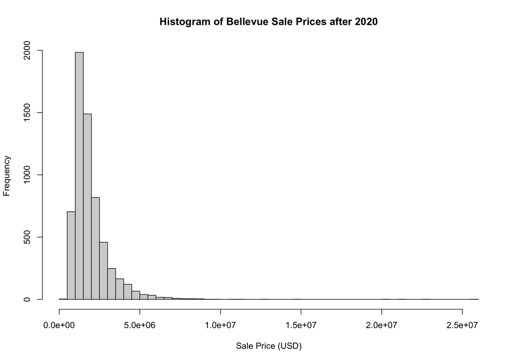

```r
# visualize the distribution of sale prices
hist(
  bellevue_after2020$sale_price,
  breaks = 50,
  main = "Histogram of Bellevue Sale Prices after 2020",
  xlab = "Sale Price (USD)"
)
```

```r
# calculate the average of bellevue_after2020$sale_price
sale_price_mean = mean(bellevue_after2020$sale_price)
```

```r
# create sample means; you don't have to anything
set.seed(79)
sample_means <- replicate(
  1000,  # we repeat the process (sample -> sample mean -> record) for 1000 times
  bellevue_after2020 %>%
    sample_n(200, replace = TRUE) %>%
    summarise(avg_price = mean(sale_price)) %>%
    pull(avg_price)
)
```

Visualize the sample means with the red line as the ‘real’ average, we found the distribution of sample means approaches normality.

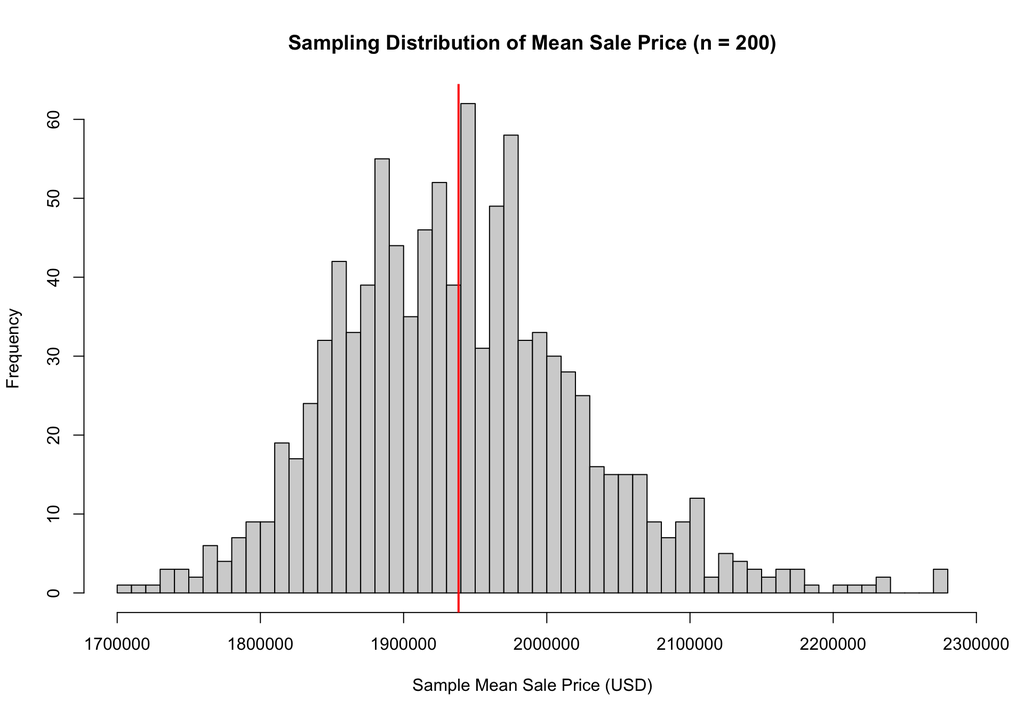

```r
hist(
  sample_means,
  breaks = 50,
  main = "Sampling Distribution of Mean Sale Price (n = 200)",
  xlab = "Sample Mean Sale Price (USD)"
)
abline(v = sale_price_mean, col = "red", lwd = 2)
```

Repeat the process with smaller sample size, such as `n = 10`, and smaller repeating time, such as 200. What did you find? What interpretation can you give for the central limit theorem from your simulation results?

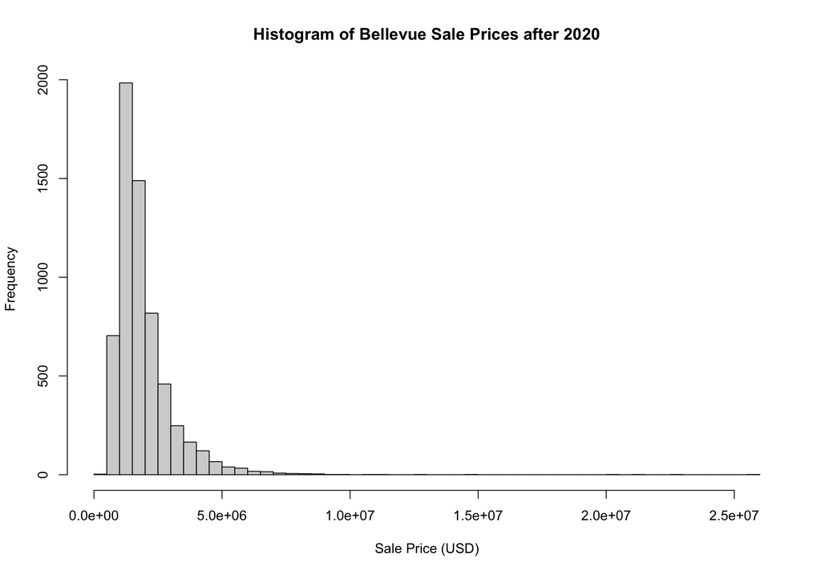

```r
bellevue_after2020 <- kingco_sales %>%
  filter(
    city == "BELLEVUE",
    sale_date >= as.Date("2020-01-01")
  )

# visualize the distribution of sale prices
hist(
  bellevue_after2020$sale_price,
  breaks = 50,
  main = "Histogram of Bellevue Sale Prices after 2020",
  xlab = "Sale Price (USD)"
)
```

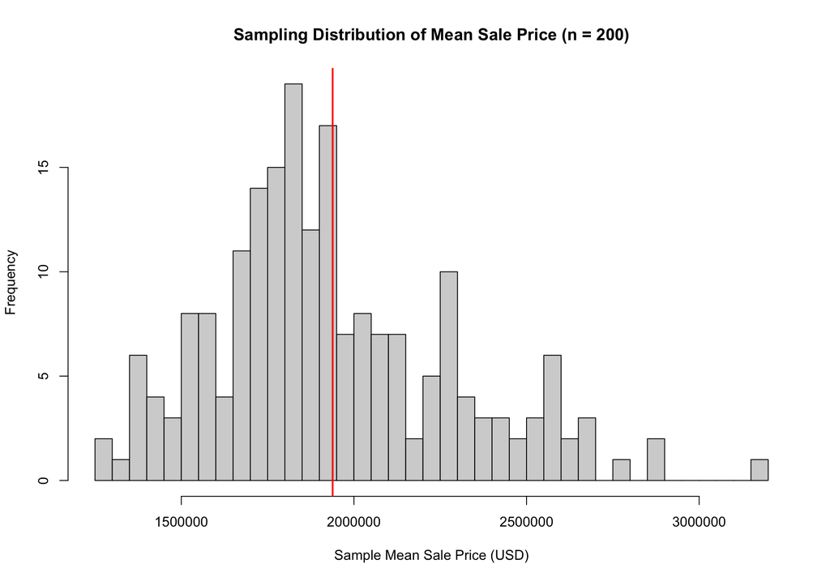

```r
# calculate the average of bellevue_after2020$sale_price
sale_price_mean = mean(bellevue_after2020$sale_price)

# create sample means; you don't have to anything
set.seed(79)
sample_means <- replicate(
  200,  # we repeat the process (sample -> sample mean -> record) for 1000 times
  bellevue_after2020 %>%
    sample_n(10, replace = TRUE) %>%
    summarise(avg_price = mean(sale_price)) %>%
    pull(avg_price)
)

hist(
  sample_means,
  breaks = 50,
  main = "Sampling Distribution of Mean Sale Price (n = 200)",
  xlab = "Sample Mean Sale Price (USD)"
)
abline(v = sale_price_mean, col = "red", lwd = 2)
```

### 📚 TODO: Explore More

**4 points**

So far, we’ve learned a lots functions, please use as many as possible to explore topics you are interested in about the King County datasets (or any other datasets you are interested iin). Please use at least 5 functions below and brief discuss your results.

- `select()` – choose columns
- `filter()` – filter rows by conditions
- `%in%` – check membership in a set
- `arrange()` + `desc()` – sort data
- `mutate()` – create or redefine variables
- `rename()` – change column names
- `recode()` and `case_when()` – recode variables and create categories
- `sample_n()` + `set.seed()` – random sampling
- `summary()` – base R quick statistics
- `summarise()` / `summarize()` – compute group summaries
- `group_by()` – aggregate by categories
- joins (`inner_join`, `left_join`, `right_join`, `full_join`) – combine datasets
- `distinct()` and `slice_max()` – handle duplicates

```r
bellevue <- kingco_sales |>
  select(city, sale_price, sqft, wfnt) |>
  filter(city == "BELLEVUE", sqft > 0) |>
  mutate(price_sqft = sale_price / sqft,
         waterfront = recode(as.character(wfnt),
                             "1" = "Waterfront",
                             "0" = "Not waterfront"))

bellevue |>
  group_by(waterfront) |>
  summarise(n = n(),
            avg_price_sqft = mean(price_sqft, na.rm = TRUE)) |>
  arrange(desc(avg_price_sqft))
```

```
## # A tibble: 5 × 3
##   waterfront         n avg_price_sqft
##   <chr>          <int>          <dbl>
## 1 6                233          1103.
## 2 7                244           776.
## 3 9                 57           675.
## 4 8                 13           493.
## 5 Not waterfront 32886           389.
```

This table shows that homes on the waterfront on Bellevue sell for a much higher price than those not on the waterfront. Makes sense!

### 📚 TODO: Using GitHub

**2 points**

After completing this lab, commit your changes with a short message, and then push them to your GitHub repository. Finally, copy the repository link from GitHub and submit it on the Canvas assignment page. Make sure that your repository is publicly visible.

## Acknowledgement

The materials are developed by Siman Ning based materials from [Dr. Feiyang Sun at UC San Diego](https://fsun.ucsd.edu), Haoyu Yue and Christian Phillips at University of Washington, [Dr. Charles Lanfear at University of Cambridge](https://clanfear.github.io).